# DATA 607 Final project

Ben Inbar, Josh Forster

2022-12-03

##### In this project, we look at immigration data from various sources to determine how the US and each individual state compares for migrant employment.

##### First, we took data from OECD.org, which compiles data for OECD member countries.

First, we pulled OECD data [here](https://stats.oecd.org/Index.aspx?DataSetCode=MIG) and uploaded to [Github](https://github.com/beninbar/DATA-607/blob/main/Final%20project/OECD.zip).

```r
library(tidyverse)
library(DescTools)
library(knitr)

temp <- tempfile()
oecd <- download.file("https://github.com/beninbar/DATA-607/blob/main/Final%20project/data/OECD.zip?raw=TRUE", temp, mode = "wb")
oecd <- unzip(temp, "OECD.csv")
oecd <- read.csv(oecd)

kable(head(oecd))
```

| CO2 | Country.of.birth.nationality | VAR | Variable | GEN | Gender | COU | Country | YEA | Year | Value | Flag.Codes | Flags |
| --- | --- | --- | --- | --- | --- | --- | --- | --- | --- | --- | --- | --- |
| AFG | Afghanistan | B11 | Inflows of foreign population by nationality | TOT | Total | AUS | Australia | 2000 | 2000 | 887 |  |  |
| AFG | Afghanistan | B11 | Inflows of foreign population by nationality | TOT | Total | AUS | Australia | 2001 | 2001 | 456 |  |  |
| AFG | Afghanistan | B11 | Inflows of foreign population by nationality | TOT | Total | AUS | Australia | 2002 | 2002 | 660 |  |  |
| AFG | Afghanistan | B11 | Inflows of foreign population by nationality | TOT | Total | AUS | Australia | 2003 | 2003 | 1015 |  |  |
| AFG | Afghanistan | B11 | Inflows of foreign population by nationality | TOT | Total | AUS | Australia | 2004 | 2004 | 1340 |  |  |
| AFG | Afghanistan | B11 | Inflows of foreign population by nationality | TOT | Total | AUS | Australia | 2005 | 2005 | 3463 |  |  |

```r
nrow(oecd)
```

```
## [1] 439521
```

```r
oecd |> group_by(Variable) |> summarize()
```

```
## # A tibble: 5 × 1
##   Variable
##   <chr>
## 1 Acquisition of nationality by country of former nationality
## 2 Inflows of foreign population by nationality
## 3 Outflows of foreign population by nationality
## 4 Stock of foreign-born population by country of birth
## 5 Stock of foreign population by nationality
```

As we can see, the data is in long format. The “Variable” column is of particular interest, and for immigration specifically, the “Inflows of foreign population by nationality” subset.

Let’s clean the dataframe: get rid of duplicate/unnecessary columns, subset to values of only inflows of foreign population, and aggregate inflows per country for all countries of birth (first left hand column).

```r
oecd <- oecd |> filter(Variable=="Inflows of foreign population by nationality") |> select(Country, Year, Value)

aggregated <- oecd |> group_by(Country, Year) |> summarize(Totals = sum(Value))
kable(head(aggregated))
```

| Country | Year | Totals |
| --- | --- | --- |
| Australia | 2000 | 217418 |
| Australia | 2001 | 257520 |
| Australia | 2002 | 239048 |
| Australia | 2003 | 247991 |
| Australia | 2004 | 295105 |
| Australia | 2005 | 327621 |

Let’s visualize this with a multi-line chart.

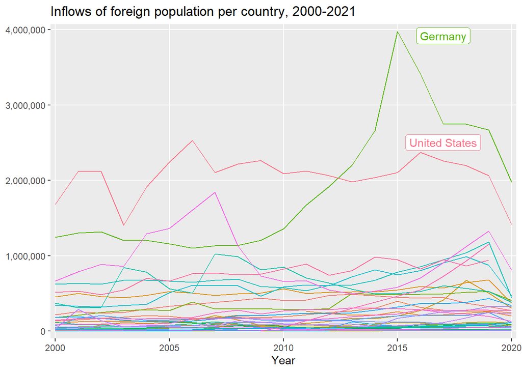

```r
library(ggrepel)

for_label <- aggregated |> filter(Year=="2015")

ggplot(data=aggregated, aes(x=Year, y=Totals, color=Country)) +
  geom_line() +
  ggtitle("Inflows of foreign population per country, 2000-2021") +
  theme(axis.title.y=element_blank(), legend.position="none", panel.grid.minor = element_blank()) +
  scale_y_continuous(labels = scales::comma, expand=c(0, 100000)) +
  scale_x_continuous(expand=c(.01, 0)) +
  geom_label_repel(data = subset(for_label, Country==c("Germany", "United States")), aes(label=Country), nudge_x=2, nudge_y=400000,     segment.color=NA)
```

It’s clear that the United States and Germany are two of the highest inflow countries by far. This tracks with the migrant crisis in 2015, when Germany opened its borders to unprecedented numbers of Middle Eastern and African refugees.

We can also run an F-test with Dunnett’s post-hoc test to compare the United States to all other OECD countries. We’re using a Dunnett’s posthoc test since in this case we have many comparisons (35 countries compared to each other), but we’re only interested in finding out if one of them (the United States) is significantly different.

```r
anova <- aov(Totals ~ Country, aggregated)
summary(anova)
```

```
##              Df    Sum Sq   Mean Sq F value Pr(>F)
## Country      34 1.599e+14 4.704e+12   126.6 <2e-16 ***
## Residuals   663 2.464e+13 3.716e+10
## ---
## Signif. codes:  0 '***' 0.001 '**' 0.01 '*' 0.05 '.' 0.1 ' ' 1
## 1 observation deleted due to missingness
```

```r
set.seed(42)
DunnettTest(x=aggregated$Totals, g=aggregated$Country, control="United States")
```

```
##
##   Dunnett's test for comparing several treatments with a control :
##     95% family-wise confidence level
##
## $`United States`
##                                     diff     lwr.ci       upr.ci   pval
## Australia-United States       -1694305.8 -1876318.1 -1512293.520 <2e-16 ***
## Austria-United States         -1835089.0 -2017101.2 -1653076.663 <2e-16 ***
## Belgium-United States         -1871133.5 -2055406.9 -1686860.059 <2e-16 ***
## Canada-United States          -1545659.4 -1727671.7 -1363647.139 <2e-16 ***
## Chile-United States           -1885067.9 -2067080.2 -1703055.616 <2e-16 ***
## Czech Republic-United States  -1973209.5 -2155221.8 -1791197.235 <2e-16 ***
## Denmark-United States         -1992414.7 -2174427.0 -1810402.425 <2e-16 ***
## Estonia-United States         -2053917.8 -2246339.1 -1861496.539 <2e-16 ***
## Finland-United States         -2025177.7 -2207190.0 -1843165.377 <2e-16 ***
## France-United States          -1703911.0 -1885923.2 -1521898.663 <2e-16 ***
## Germany-United States          -188385.4  -370397.7    -6373.092 0.0369 *
## Greece-United States          -1991958.9 -2187675.0 -1796242.743 <2e-16 ***
## Hungary-United States         -2006957.7 -2188970.0 -1824945.425 <2e-16 ***
## Iceland-United States         -2051186.4 -2233198.7 -1869174.092 <2e-16 ***
## Ireland-United States         -2001492.3 -2183504.6 -1819480.044 <2e-16 ***
## Israel-United States          -2002784.3 -2184796.6 -1820771.996 <2e-16 ***
## Italy-United States           -1449409.9 -1631422.1 -1267397.568 <2e-16 ***
## Japan-United States           -1359831.7 -1541844.0 -1177819.425 <2e-16 ***
## Korea-United States           -1462142.3 -1644154.6 -1280129.996 <2e-16 ***
## Latvia-United States          -2055863.3 -2248284.6 -1863442.069 <2e-16 ***
## Luxembourg-United States      -2027276.0 -2209288.2 -1845263.663 <2e-16 ***
## Mexico-United States          -2015675.7 -2197688.0 -1833663.377 <2e-16 ***
## Netherlands-United States     -1820489.5 -2002501.8 -1638477.235 <2e-16 ***
## New Zealand-United States     -1894176.7 -2076189.0 -1712164.425 <2e-16 ***
## Norway-United States          -1967093.4 -2149105.7 -1785081.092 <2e-16 ***
## Poland-United States          -1936478.6 -2118490.9 -1754466.330 <2e-16 ***
## Portugal-United States        -1952034.7 -2134047.0 -1770022.377 <2e-16 ***
## Slovak Republic-United States -2053697.0 -2235709.3 -1871684.758 <2e-16 ***
## Slovenia-United States        -2026627.9 -2230123.8 -1823131.931 <2e-16 ***
## Spain-United States           -1132864.6 -1314876.9  -950852.330 <2e-16 ***
## Sweden-United States          -1899232.0 -2081244.3 -1717219.758 <2e-16 ***
## Switzerland-United States     -1822637.5 -2004649.8 -1640625.187 <2e-16 ***
## Türkiye-United States         -1492281.9 -1765300.3 -1219263.423 <2e-16 ***
## United Kingdom-United States  -1299583.3 -1483856.7 -1115309.909 <2e-16 ***
##
## ---
## Signif. codes:  0 '***' 0.001 '**' 0.01 '*' 0.05 '.' 0.1 ' ' 1
```

#### Indeed, the only other country that shows less significant of a difference in migration (but notably, is still significant), is Germany!